# Category Paths

S. Aguinaga

10/21/2014

## Brain Dump

*This document is the work-pad for this project, so this document will include notes about Rsdutio and howtos.*

## Project Files

Project Folder:

- ~/CategoryPaths/

Scripts:

- CategoryPaths/scripts/

Data Files:

- /data/zliu8/ssssp/
- /data/zliu8/our_algo##

## Introduction

100 source nodes (wikipedia.page.page_id) were selected and these are embeded in the filenames for the single-source-shortest-paths. Below the source folder and sample of the files are listed.

```
saguinag@dsg1:~$  ls /data/zliu8/sssp/ | head
sssp_1018340.txt
sssp_10568.txt
sssp_10671.txt
sssp_11054.txt
sssp_11121.txt
sssp_11125639.txt
```

#### Games

Using these filenames, for each source node, the games (uid) starting with a given source node are extracted to find the end-nodes (destination page_id).

```
scripts/games_given_sssp.py /data/zliu8/sssp/
```

The output goes in folder gamesDatafiles.

```
saguinag@dsg1:~/CategoryPaths/gamesDatafiles$ ls
1018340_wpgame_games.dat
10568_wpgame_games.dat
10671_wpgame_games.dat
...

cat 1018340_wpgame_games.dat | head
src_pg,game,end_pg
1018340,08f2f5bb32504c3d8b5ad3dbc6ae92d2,19011063
1018340,fa2b9a1da0b64682b97f6344c262c0b5,9147836
1018340,3279c75c8b0341bbac09c3b44d0f0856,49603
1018340,999aaaf3c86c40ed8c2bd59007d487c5,16245
```

#### Human Paths

For each game, the users that played each game are extracted and count the number of clicks for games started and finished. Not all games were completed, but for those that were we can get the users that played a given game.

```
humanPathsSsspScores.py ~/CategoryPaths/gamesDatafiles/
```

Here is an example of completed games and the user.

```
ec81d184fd444570ab65d1830dee41bc joppi
16a5df42c16247c68226c12fa50a7384 Bellerophonia
16a5df42c16247c68226c12fa50a7384 ChrisOk1
16a5df42c16247c68226c12fa50a7384 Guest24F1A079FA64422583F360DBB
16a5df42c16247c68226c12fa50a7384 Guest35F9CFA0878144C79535FAE96
16a5df42c16247c68226c12fa50a7384 Guest4C81573A4FED4FC6908618880
```

The distribution of the cliks for all games played and completed.

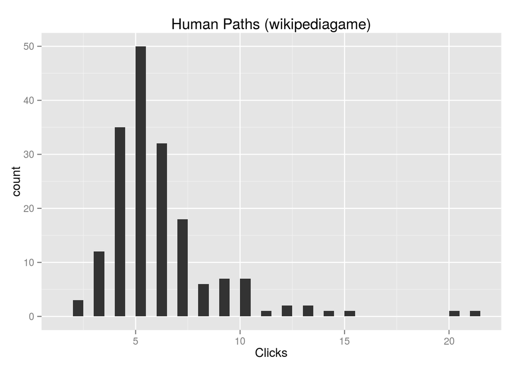

#### Shortest Paths

The distribution of the shortest paths: single source shortest paths (sssp) for each games’ end-points.

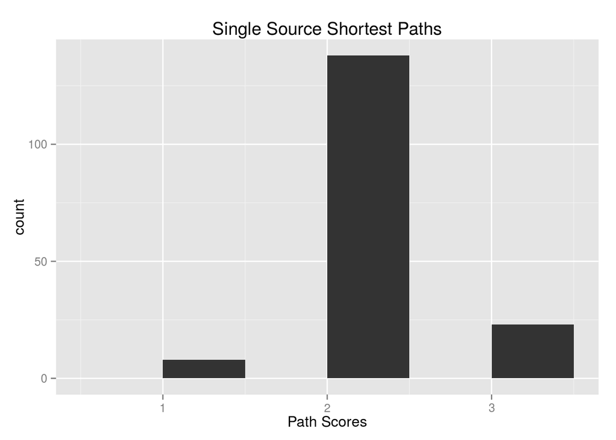

## Category Paths vs Shortest Paths

Below is a figure showing the number of hops for category paths (cp) and shortest paths (sp).

*Output files in ~/CategoryPaths/ourAlgoScores/ consist of both, shrotest paths and category paths. The files are read into a list and a single data.frame holds the entire set of paths.*

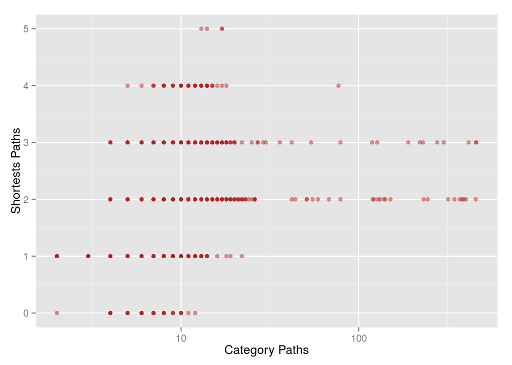

In the next section we show how the two sets of paths correlate.

**Testing for significant difference between the paths**

```
##
##  Wilcoxon signed rank test with continuity correction
##
## data:  data$sp and data$cp
## V = 0, p-value < 2.2e-16
## alternative hypothesis: true location shift is not equal to 0
```

Checking for the significance test for Kendall’s Tau-b, but first the correlation:

```
> cor(m, method="kendall",use='pairwise')
          [,1]      [,2]
[1,] 1.0000000 0.2929309
[2,] 0.2929309 1.0000000
```

To test the null hypothesis to find the p-value:

```
cor.test(data$sp,data$cp, method='kendall')

  Kendall's rank correlation tau

data:  data$sp and data$cp
z = 58.9618, p-value < 2.2e-16
alternative hypothesis: true tau is not equal to 0
sample estimates:
      tau
0.2929309
```

## Human Paths vs Category Paths

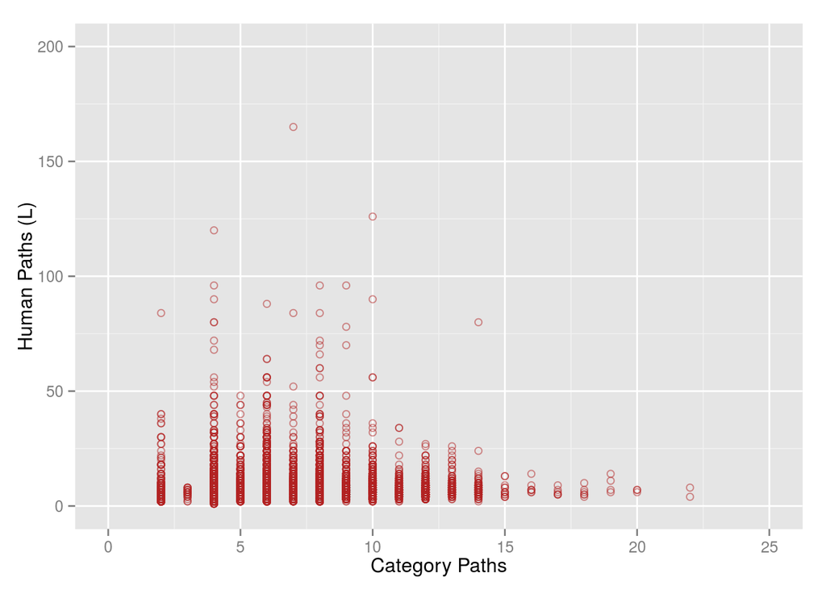

The Distribution of Category Paths and Human Paths

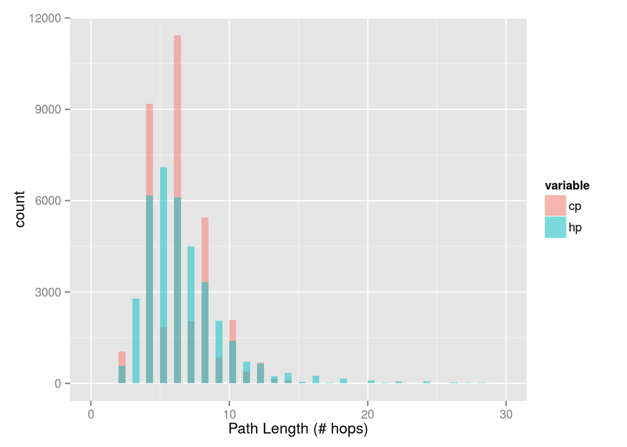

## Summary

*This section shows the plots of highest interest*

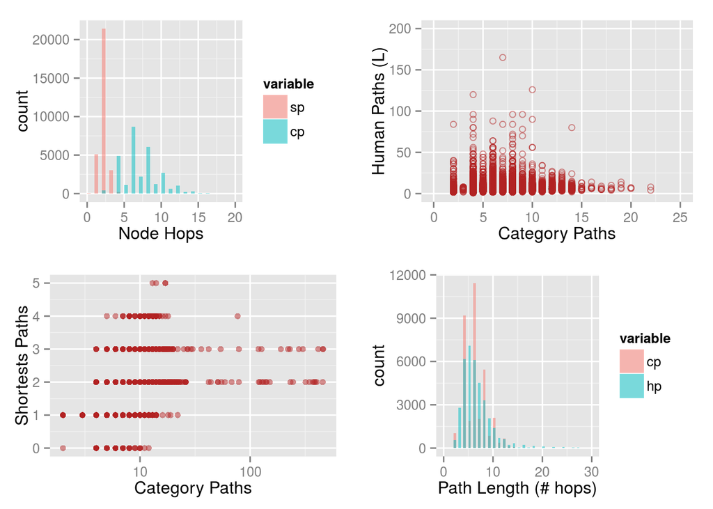